# Titanic: Machine Learning from Disaster

```r
## Data preparation

# Reading in the data
test_init <- read_csv("data/test.csv")
train_init <- read_csv("data/train.csv")

data <- train_init

# Order columns
data <- data %>% select(-Survived, Survived)
data <- as.data.frame(data)
```

Data exploration

The gender submission data is incorrect. I will still use the test set for EDA purposes.

```r
glimpse(data)
```

```
Observations: 891
Variables: 12
$ PassengerId <int> 1, 2, 3, 4, 5, 6, 7, 8, 9, 10, 11, 12, 13, 14, 15, 16, 17, 18, 19, 20, 21, 22, 23, 24, 25, 26, 27, 28, 29, 30, 31, 32, 33, 34, 35, 36, 37, 38, 39, 40, 41,...
$ Pclass      <int> 3, 1, 3, 1, 3, 3, 1, 3, 3, 2, 3, 1, 3, 3, 3, 2, 3, 2, 3, 3, 2, 2, 3, 1, 3, 3, 3, 1, 3, 3, 1, 1, 3, 2, 1, 1, 3, 3, 3, 3, 3, 2, 3, 2, 3, 3, 3, 3, 3, 3, 3, 3...
$ Name        <chr> "Braund, Mr. Owen Harris", "Cumings, Mrs. John Bradley (Florence Briggs Thayer)", "Heikkinen, Miss. Laina", "Futrelle, Mrs. Jacques Heath (Lily May Peel)"...
$ Sex         <chr> "male", "female", "female", "female", "male", "male", "male", "male", "female", "female", "female", "female", "male", "male", "female", "female", "male", ...
$ Age         <dbl> 22.0, 38.0, 26.0, 35.0, 35.0, NA, 54.0, 2.0, 27.0, 14.0, 4.0, 58.0, 20.0, 39.0, 14.0, 55.0, 2.0, NA, 31.0, NA, 35.0, 34.0, 15.0, 28.0, 8.0, 38.0, NA, 19.0...
$ SibSp       <int> 1, 1, 0, 1, 0, 0, 0, 3, 0, 1, 1, 0, 0, 1, 0, 0, 4, 0, 1, 0, 0, 0, 0, 0, 3, 1, 0, 3, 0, 0, 0, 1, 0, 0, 1, 1, 0, 0, 2, 1, 1, 1, 0, 1, 0, 0, 1, 0, 2, 1, 4, 0...
$ Parch       <int> 0, 0, 0, 0, 0, 0, 0, 1, 2, 0, 1, 0, 0, 5, 0, 0, 1, 0, 0, 0, 0, 0, 0, 0, 1, 5, 0, 2, 0, 0, 0, 0, 0, 0, 0, 0, 0, 0, 0, 0, 0, 0, 0, 2, 0, 0, 0, 0, 0, 0, 1, 0...
$ Ticket      <chr> "A/5 21171", "PC 17599", "STON/O2. 3101282", "113803", "373450", "330877", "17463", "349909", "347742", "237736", "PP 9549", "113783", "A/5. 2151", "34708...
$ Fare        <dbl> 7.2500, 71.2833, 7.9250, 53.1000, 8.0500, 8.4583, 51.8625, 21.0750, 11.1333, 30.0708, 16.7000, 26.5500, 8.0500, 31.2750, 7.8542, 16.0000, 29.1250, 13.0000...
$ Cabin       <chr> NA, "C85", NA, "C123", NA, NA, "E46", NA, NA, NA, "G6", "C103", NA, NA, NA, NA, NA, NA, NA, NA, NA, "D56", NA, "A6", NA, NA, NA, "C23 C25 C27", NA, NA, NA...
$ Embarked    <chr> "S", "C", "S", "S", "S", "Q", "S", "S", "S", "C", "S", "S", "S", "S", "S", "S", "Q", "S", "S", "C", "S", "S", "Q", "S", "S", "S", "C", "S", "Q", "S", "C",...
$ Survived    <int> 0, 1, 1, 1, 0, 0, 0, 0, 1, 1, 1, 1, 0, 0, 0, 1, 0, 1, 0, 1, 0, 1, 1, 1, 0, 1, 0, 0, 1, 0, 0, 1, 1, 0, 0, 0, 1, 0, 0, 1, 0, 0, 0, 1, 1, 0, 0, 1, 0, 0, 0, 0...
```

```r
table(data$Sex)
```

```
female   male
   314    577
```

```r
table(data$Pclass)
```

```
  1   2   3
216 184 491
```

We have three passenger classes. Most people belong in third class.

```r
data %>% filter(!is.na(Age)) %>% summarise('Mean Age' = mean(Age), 'Median Age' = median(Age))
```

| Mean Age | Median Age |
| --- | --- |
| 29.69912 | 28 |

```r
sum(is.na(data$SibSp))
```

```
[1] 0
```

I think the family could be rolled into a single variable. Potentially, name titles could be classified based on prestige.

- Number of cabins
- The first letter of the cabin? What does it mean?

## Basic feature engineering

```r
data <- data %>% mutate(no_family = SibSp + Parch)
data <- data %>% select(-c(PassengerId, SibSp, Parch, Ticket, Cabin))
data$Pclass <- factor(data$Pclass)
data$Name <- factor(data$Name)
data$Sex <- factor(data$Sex)
data$Embarked <- factor(data$Embarked)
data$Survived <- factor(data$Survived)
```

The values are not imputed, there are missing values all around. In this case, I want the model to run as bad as possible, with the least amount of info. After that, I will do more feature engineering based on other Kaggle answers and see how it improves my algorithm.

## Machine learning prep

```r
set.seed(420)
```

Randomising the dataset

```r
data_sampled <- sample_n(data, length(data[,1]))
```

Splitting into training and test set (70/30%), removing test label

```r
train <- data_sampled[1:round(0.7*length(data_sampled[,1])),]
test <- anti_join(data_sampled, train)
test_answer <- test$Survived
test <- test %>% select(-Survived)
test$Age[is.na(test$Age)] <- median(na.omit(test$Age))
test$Embarked[75] <- "S"
```

```r
rf_model <- randomForest(factor(Survived) ~ Pclass + Sex + Age + Embarked + no_family, data = train, na.action = na.roughfix)
```

```r
rf_model
```

```
Call:
 randomForest(formula = factor(Survived) ~ Pclass + Sex + Age +      Embarked + no_family, data = train, na.action = na.roughfix)
               Type of random forest: classification
                     Number of trees: 500
No. of variables tried at each split: 2

        OOB estimate of  error rate: 15.71%
Confusion matrix:
    0   1 class.error
0 377  20  0.05037783
1  78 149  0.34361233
```

The model ran successfully.

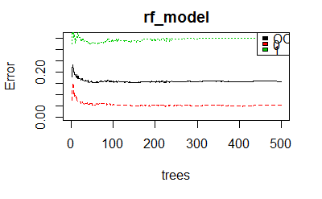

```r
# Show model error
plot(rf_model, ylim=c(0,0.36))
legend('topright', colnames(rf_model$err.rate), col=1:3, fill=1:3)
```

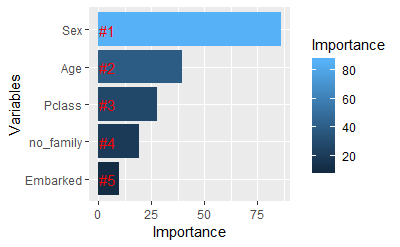

```r
importance <- importance(rf_model)
varImportance <- data.frame(Variables = row.names(importance),
                            Importance = round(importance[ ,'MeanDecreaseGini'],2))
rankImportance <- varImportance %>%
  mutate(Rank = paste0('#',dense_rank(desc(Importance))))
ggplot(rankImportance, aes(x = reorder(Variables, Importance),
    y = Importance, fill = Importance)) +
  geom_bar(stat='identity') +
  geom_text(aes(x = Variables, y = 0.5, label = Rank),
    hjust=0, vjust=0.55, size = 4, colour = 'red') +
  labs(x = 'Variables') +
  coord_flip()
```

```r
prediction <- predict(rf_model, test)
output <- data.frame(test, test_answer, prediction)
```

```r
accuracy <- sum(output$prediction == output$test_answer) / nrow(output) * 100
paste0("Model accuracy: ", accuracy, "%")
```

```
[1] "Model accuracy: 77.5280898876404%"
```

The most basic metric we can use is model accuracy. In this case, it is 77.52%.

```r
survived_percent <- sum(as.numeric(as.character(data$Survived))) / nrow(data) * 100
100 - survived_percent
```

```
[1] 61.61616
```

```r
confusionMatrix(output$prediction, output$test_answer, positive = "1")
```

```
Confusion Matrix and Statistics

          Reference
Prediction   0   1
         0 136  44
         1  16  71

               Accuracy : 0.7753
                 95% CI : (0.7204, 0.8239)
    No Information Rate : 0.5693
    P-Value [Acc > NIR] : 1.446e-12

                  Kappa : 0.5278
 Mcnemar's Test P-Value : 0.0004909

            Sensitivity : 0.6174
            Specificity : 0.8947
         Pos Pred Value : 0.8161
         Neg Pred Value : 0.7556
             Prevalence : 0.4307
         Detection Rate : 0.2659
   Detection Prevalence : 0.3258
      Balanced Accuracy : 0.7561

       'Positive' Class : 1
```

Ok, so don’t forget to set the positive class in the confusion matrix command. Alright, so the next step now is to go back to data cleaning and feature engineering and see how the accuracy and Kappa can be improved.

There is much improvement to be made to improve the performance of the model, but it’s not a bad start.

I want to see the progress of the model, so I will return to feature engineering below.

## Feature engineering round 2

```r
summary(data)
```

```
 Pclass                                     Name         Sex           Age             Fare        Embarked   Survived   no_family
 1:216   Abbing, Mr. Anthony                  :  1   female:314   Min.   : 0.42   Min.   :  0.00   C   :168   0:549    Min.   : 0.0000
 2:184   Abbott, Mr. Rossmore Edward          :  1   male  :577   1st Qu.:20.12   1st Qu.:  7.91   Q   : 77   1:342    1st Qu.: 0.0000
 3:491   Abbott, Mrs. Stanton (Rosa Hunt)     :  1                Median :28.00   Median : 14.45   S   :644            Median : 0.0000
         Abelson, Mr. Samuel                  :  1                Mean   :29.70   Mean   : 32.20   NA's:  2            Mean   : 0.9046
         Abelson, Mrs. Samuel (Hannah Wizosky):  1                3rd Qu.:38.00   3rd Qu.: 31.00                       3rd Qu.: 1.0000
         Adahl, Mr. Mauritz Nils Martin       :  1                Max.   :80.00   Max.   :512.33                       Max.   :10.0000
         (Other)                              :885                NA's   :177
```

- Alrighty. We have missing values in Age and Embarked.
- We can split out the titles and group them together. This is most likely going to be a combination of age and sex. But, knowing the title but not age is going to give us an edge in imputing the large number of missing age values. Everything for predictive accuracy.

### Creating title feature

```r
str_replace("^.*, ", "", data$Name)
```

```
Error: Empty `pattern` not supported
```

```r
table(data$title)
```

```
High_rank    Master      Miss        Mr       Mrs
       23        40       185       517       126
```

Looking good. There are some weird values: * Mlle = Madmoiselle (French) * Mme = Madame (French) * Ms = Miss * Rev = reverend? * Jonkheer - low ranking noble * Master - young male (child)

I would create a category for important people with rare names. It is sort of a saying that the captain should leave a sinking ship last.

The title feature is now ready.

### Imputing Embarked missing value

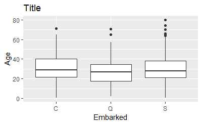

```r
data %>% ggplot(aes(x = Embarked, y = Age)) +
  geom_boxplot() +
  ggtitle("Title")
```

```r
table(data$Embarked, data$Sex)
```

```
    female male
  C     73   95
  Q     36   41
  S    203  441
```

Good question: How to impute the missing values of the embarked. Based on their age and sex, I would wager that they embarked from C. In another kernel, this was calculated based on the ticket price.

### Imputing missing age

Based on Kaggle’s kernel, it would make sense to impute the missing age values based on a linear model incorporating the variables I’m working with.

```r
anova(age_lm)
```

```
Analysis of Variance Table

Response: Age
           Df Sum Sq Mean Sq  F value    Pr(>F)
Sex         1   1308  1308.4   9.2684 0.0024184 **
Fare        1   2000  2000.5  14.1708 0.0001809 ***
Embarked    2    104    52.1   0.3693 0.6913430
no_family   1  14714 14713.7 104.2275 < 2.2e-16 ***
title       4  32947  8236.7  58.3463 < 2.2e-16 ***
Residuals 704  99383   141.2
---
Signif. codes:  0 ‘***’ 0.001 ‘**’ 0.01 ‘*’ 0.05 ‘.’ 0.1 ‘ ’ 1
```

It appears that the Embarkment is not a significant predictor of age.

```r
anova(age_lm)
```

```
Analysis of Variance Table

Response: Age
           Df Sum Sq Mean Sq  F value    Pr(>F)
Sex         1   1308  1308.4   9.2694 0.0024168 **
Fare        1   2000  2000.5  14.1723 0.0001807 ***
no_family   1  14791 14790.6 104.7836 < 2.2e-16 ***
title       4  32703  8175.7  57.9205 < 2.2e-16 ***
Residuals 706  99654   141.2
---
Signif. codes:  0 ‘***’ 0.001 ‘**’ 0.01 ‘*’ 0.05 ‘.’ 0.1 ‘ ’ 1
```

```r
summary(age_lm)
```

```
Call:
lm(formula = Age ~ Sex + Fare + no_family + title, data = na.omit(data))

Residuals:
    Min      1Q  Median      3Q     Max
-27.220  -8.389  -1.577   6.391  46.611

Coefficients:
              Estimate Std. Error t value Pr(>|t|)
(Intercept)  41.640196   6.873218   6.058 2.24e-09 ***
Sexmale       3.535985   7.382692   0.479  0.63212
Fare          0.045479   0.008711   5.221 2.34e-07 ***
no_family    -1.834726   0.354027  -5.182 2.86e-07 ***
titleMaster -35.622650   3.544218 -10.051  < 2e-16 ***
titleMiss   -19.888365   6.934587  -2.868  0.00425 **
titleMr     -13.151345   2.790960  -4.712 2.95e-06 ***
titleMrs     -4.933115   6.968690  -0.708  0.47924
---
Signif. codes:  0 ‘***’ 0.001 ‘**’ 0.01 ‘*’ 0.05 ‘.’ 0.1 ‘ ’ 1

Residual standard error: 11.88 on 706 degrees of freedom
Multiple R-squared:  0.3377,    Adjusted R-squared:  0.3311
F-statistic: 51.42 on 7 and 706 DF,  p-value: < 2.2e-16
```

```r
data_test$Age <- predict(age_lm, data[is.na(data$Age),])
```

```
Error in `$<-.data.frame`(`*tmp*`, Age, value = c(`6` = 32.4095115045292,  :
  replacement has 177 rows, data has 891
```

The data is clean and ready to go.

## Random Forest Round 2

Randomising the dataset

Splitting into training and test set (70/30%), removing test label

```r
test <- anti_join(data_sampled, train)
```

```r
rf_model
```

```
Call:
 randomForest(formula = factor(Survived) ~ Pclass + Sex + Age +      Fare + Embarked + no_family, data = train)
               Type of random forest: classification
                     Number of trees: 500
No. of variables tried at each split: 2

        OOB estimate of  error rate: 16.03%
Confusion matrix:
    0   1 class.error
0 368  29  0.07304786
1  71 156  0.31277533
```

The model ran successfully.

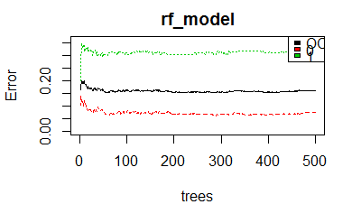

```r
# Show model error
plot(rf_model, ylim=c(0,0.36))
legend('topright', colnames(rf_model$err.rate), col=1:3, fill=1:3)
```

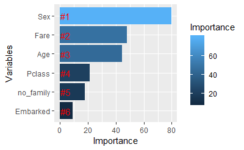

```r
importance <- importance(rf_model)
varImportance <- data.frame(Variables = row.names(importance),
                            Importance = round(importance[ ,'MeanDecreaseGini'],2))
rankImportance <- varImportance %>%
  mutate(Rank = paste0('#',dense_rank(desc(Importance))))
ggplot(rankImportance, aes(x = reorder(Variables, Importance),
    y = Importance, fill = Importance)) +
  geom_bar(stat='identity') +
  geom_text(aes(x = Variables, y = 0.5, label = Rank),
    hjust=0, vjust=0.55, size = 4, colour = 'red') +
  labs(x = 'Variables') +
  coord_flip()
```

```r
prediction <- predict(rf_model, test)
output <- data.frame(test, test_answer, prediction)
```

```r
accuracy <- sum(output$prediction == output$test_answer) / nrow(output) * 100
paste0("Model accuracy: ", accuracy, "%")
```

```
[1] "Model accuracy: 79.0262172284644%"
```

I improved 1.5% on the overall model accuracy.

```r
100 - survived_percent
```

```
[1] 61.61616
```

```r
confusionMatrix(output$prediction, output$test_answer, positive = "1")
```

```
Confusion Matrix and Statistics

          Reference
Prediction   0   1
         0 134  38
         1  18  77

               Accuracy : 0.7903
                 95% CI : (0.7365, 0.8375)
    No Information Rate : 0.5693
    P-Value [Acc > NIR] : 2.553e-14

                  Kappa : 0.5631
 Mcnemar's Test P-Value : 0.01112

            Sensitivity : 0.6696
            Specificity : 0.8816
         Pos Pred Value : 0.8105
         Neg Pred Value : 0.7791
             Prevalence : 0.4307
         Detection Rate : 0.2884
   Detection Prevalence : 0.3558
      Balanced Accuracy : 0.7756

       'Positive' Class : 1
```

The model accuracy improved a little bit. It’s definitely a step in the right direction. How else could I improve model performance? Trying a different technique.

```r
set.seed(420)
data_sampled <- sample_n(data, length(data[,1]))
```

Splitting into training and test set (70/30%), removing test label

```r
train <- data_sampled[1:round(0.7*length(data_sampled[,1])),]
test <- anti_join(data_sampled, train)
test_answer <- test$Survived
train <- train %>% select(-Name)
test <- test %>% select(-Name)
```

```r
h2o.init()
```

[output not shown]

```r
test <- as.h2o(test)
```

[output not shown]

[output cut: 25 more lines]

```r
print(lb, n = nrow(lb))
```

```
[35 rows x 6 columns]
```

```r
pred <- h2o.predict(aml, test)
```

```r
confusionMatrix(test_out$predict, test_out$Survived, positive = "1")
```

```
Confusion Matrix and Statistics

          Reference
Prediction   0   1
         0 130  32
         1  22  83

               Accuracy : 0.7978
                 95% CI : (0.7445, 0.8443)
    No Information Rate : 0.5693
    P-Value [Acc > NIR] : 2.973e-15

                  Kappa : 0.5832
 Mcnemar's Test P-Value : 0.2207

            Sensitivity : 0.7217
            Specificity : 0.8553
         Pos Pred Value : 0.7905
         Neg Pred Value : 0.8025
             Prevalence : 0.4307
         Detection Rate : 0.3109
   Detection Prevalence : 0.3933
      Balanced Accuracy : 0.7885

       'Positive' Class : 1
```

```r
h2o.shutdown()
y
```

```
[1] TRUE
```

I managed to squeeze out just a little bit of extra predictive power compared to the basic Random Forest Model.

Kappa of 0.58

## Final training of the model and predicting final output

### Feature engineering with full dataset (Please don’t forget to do this next time)

```r
data <-

data <- data %>% mutate(no_family = SibSp + Parch)
data <- data %>% select(-c(PassengerId, SibSp, Parch, Ticket, Cabin))

data$Pclass <- factor(data$Pclass)
data$Name <- factor(data$Name)
data$Sex <- factor(data$Sex)
data$Embarked <- factor(data$Embarked)
data$Survived <- factor(data$Survived)
```

```r
data$Name <- as.character(data$Name)
data$title <- sub("^.*, ", "", data$Name)
data$title <- sub("\\..*", "", data$title)
```

```r
data$title <- gsub("Mlle", "Miss", data$title)
data$title <- gsub("Mme", "Mrs", data$title)
data$title <- gsub("Ms", "Miss", data$title)

# Aggregating important people
data$title <- gsub("Capt|Col|Don|Dr|Jonkheer|Lady|Major|Rev|Sir|the Countess", "High_rank", data$title)
```

```r
data %>% ggplot(aes(x = Embarked, y = Age)) +
  geom_boxplot() +
  ggtitle("Title")
```

```r
data[is.na(data$Embarked), "Embarked"] <- "C"
```

```r
age_lm <- lm(Age ~ Sex + Fare + Embarked + no_family + title, data = data)
```

```r
age_lm <- lm(Age ~ Sex + Fare + no_family + title, data = na.omit(data))
```

```r
data_test <- data
data[is.na(data$Age), "Age"] <- predict(age_lm, data[is.na(data$Age),])

# If age is negative, turn into 0
data$Age <- ifelse(data$Age < 0, 0, data$Age)

# Round age to half number
data$Age <- round(data$Age, 1)
```

## What am I doing?

```r
h2o.init()
```

```r
y <- "Survived"
x <- setdiff(names(train), y)
```

```r
train[,y] <- as.factor(train[,y])
test[,y] <- as.factor(test[,y])

train <- as.h2o(train)
test <- as.h2o(test)
```

```r
aml <- h2o.automl(x = x, y = y,
                  training_frame = train,
                  max_models = 10,
                  seed = 1)

lb <- aml@leaderboard
print(lb, n = nrow(lb))
aml@leader
```

```r
pred <- h2o.predict(aml, test)
```

```r
test_out <- as.data.frame(test)
pred_out <- as.data.frame(pred)
test_out$predict <- pred_out$predict
```